# dHCP diffusion Data exploration

# Importing the data:

The full dataset is divided into the preterm and term dataset. The preterm cohort is further selected to choose those with term at scan.

```r
european_diffusion_dataset.term<-read.csv('./preprocessed_data/diffusion/european_ID_diffusion_dataset_term_without_outliers.csv')
```

# Collapsing the diffusion regional space

## Retaining non-zero connections

```r
to_remove_list=c()
for (i in 6:4010){
  if (length(which(european_diffusion_dataset.term[,i]==0))/151>0){
    to_remove_list<-c(to_remove_list,i)
  }
}
```

This retained 2513 connections.

```r
european_diffusion_dataset.term.removed_zeros<-subset(european_diffusion_dataset.term,select=-to_remove_list)
write.csv(european_diffusion_dataset.term.removed_zeros,'./reduced_european_diffusion_dataset.csv',row.names=FALSE)
```

```r
formula_lm<-function(y,covariates=c('GA.at.birth','PMA.at.birth','Gender','Anc_PC1','Anc_PC2','Anc_PC3'),prs,with_interaction=FALSE){
  " this function creates a linear model in R with a custom function.
  Arguments:
    y (str): the independent variables- here is the diffusion value.
    covariates (str): the covariates used in the linear model aside from the prs.
    prs (str): the PRS values.
    with_interaction (bool): if True, the prs * covariate is added as additional covariate term.
  Return:
    linear model formula used in the lm R function.
  Example:
    > formula_lm(colnames(european_diffusion_dataset.term)[7],prs=PRS_scores[1],with_interaction = FALSE)
    PreCG.R_PreCG.L ~ GA.at.birth + PMA.at.birth + Gender + X1e.08
  "
  if (length(covariates)==0){
    as.formula(paste(y,prs,sep = '~'))
  }
  else{
    if (with_interaction){
      as.formula(paste(y,paste(c(covariates,prs,paste(prs,covariates,sep='*')),collapse='+'),sep='~'))
    }
    else{
      as.formula(paste(y,paste(c(covariates,prs),collapse='+'),sep='~'))
    }
  }
}

PRS_scores=c('X1e.08','X1e.07','X1e.06','X1e.05','X0.0001','X0.001','X0.01','X0.05','X0.1','X0.5','X1')
# example:
print(formula_lm(colnames(european_diffusion_dataset.term)[6],prs=PRS_scores[1],with_interaction = FALSE))
```

```
PreCG.R_PreCG.L ~ GA.at.birth + PMA.at.birth + Gender + Anc_PC1 +
    Anc_PC2 + Anc_PC3 + X1e.08
<environment: 0x7fb56870c3e8>
```

## Visualising the babies’ risk scores across PRS thresholds.

```r
# library(ggplot2)
PRS_scores=c('1e-08','1e-07','1e-06','1e-05','1e-04','1e-03','1e-02','0.05','0.1','0.5','1')
PRS_df=data.frame(V1=c())
for (i in 2716:2726){
  PRS_df<-rbind(PRS_df,data.frame(V1=c(european_diffusion_dataset.term.removed_zeros[,i])))
}

par(mfrow=c(1,2))
PRS_df$PRS_thresholds=rep(1:11,each=151)
bpt<-boxplot(V1~PRS_thresholds,data=PRS_df,axes=FALSE)
axis(2,at=seq(-0.01,0.03,by=0.01),labels=seq(-0.01,0.03,by=0.01))
```

```r
axis(1,at=1:11,labels=PRS_scores,las=3)
lines(1:11,bpt$stats[3,])
```

```r
title(ylab = 'risk scores values', xlab='PRS Thresholds')

bpt<-boxplot(V1~PRS_thresholds,data=PRS_df[PRS_df$PRS_thresholds>5,],axes=FALSE)
```

```r
axis(2,at=seq(-0.0025,0.005,by=0.001),labels=seq(-0.0025,0.005,by=0.001))
axis(1,at=1:6,labels=PRS_scores[6:11],las=3)
```

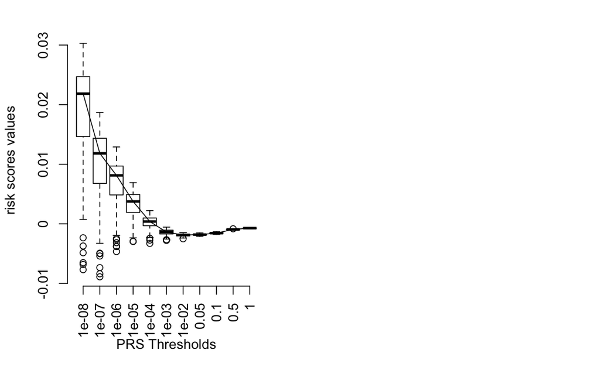

```r
lines(1:6,bpt$stats[3,])
title(ylab = 'risk scores values', xlab='PRS Thresholds')
```

As we take more stringent criteria for SNPs, we see there is larger range of PRS values. As the PRS thresholds become less stringent, the shape becomes normal distribution.

# Performing univariate test to each connection with PRS, GA, PMA and Gender and Anc_PCs as covariates.

```r
# df.allPRS_nointeraction<-data.frame()
#
# for (prs in PRS_scores){
#   for (i in 6:2518){
#     connection=colnames(european_diffusion_dataset.term.removed_zeros)[i]
#     simple.regression<-lm(formula_lm(connection,prs=prs,with_interaction = FALSE),data=european_diffusion_dataset.term.removed_zeros)
#     simple.regression.summary<-summary(simple.regression)
#     temp_row<-data.frame(Connection=connection,
#       prs_pval=simple.regression.summary$coefficients[prs,4],
#       prs_coef=simple.regression.summary$coefficients[prs,1],
#       GA_pval=simple.regression.summary$coefficients['GA.at.birth',4],
#       GA_coef=simple.regression.summary$coefficients['GA.at.birth',1],
#       PMA_pval=simple.regression.summary$coefficients['PMA.at.birth',4],
#       PMA_coef=simple.regression.summary$coefficients['PMA.at.birth',1],
#       Gender_pval=simple.regression.summary$coefficients['Gender',4],
#       Gender_coef=simple.regression.summary$coefficients['Gender',1],
#       Anc_PC1_pval=simple.regression.summary$coefficients['Anc_PC1',4],
#       Anc_PC1_coef=simple.regression.summary$coefficients['Anc_PC1',1],
#       Anc_PC2_pval=simple.regression.summary$coefficients['Anc_PC2',4],
#       Anc_PC2_coef=simple.regression.summary$coefficients['Anc_PC2',1],
#       Anc_PC3_pval=simple.regression.summary$coefficients['Anc_PC3',4],
#       Anc_PC3_coef=simple.regression.summary$coefficients['Anc_PC3',1],
#       Adj_R_square=simple.regression.summary$adj.r.squared,
#       model_pval=as.double(pf(simple.regression.summary$fstatistic[1],simple.regression.summary$fstatistic[2],simple.regression.summary$fstatistic[3],lower.tail=FALSE)),
#       PRS_threshold=prs
#       )
#     df.allPRS_nointeraction<-rbind(df.allPRS_nointeraction,temp_row)
#   }
# }
```

```r
#write.csv(df.allPRS_nointeraction,'./observed_univariate_test.csv',row.names=FALSE)
df.allPRS_nointeraction=read.csv('./preprocessed_data/diffusion/term/obsv_diffusion_term_p_val.csv')
head(df.allPRS_nointeraction)
```

|  | Connection | const_pval | GA.at.birth_pval | PMA.at.birth_pval | Gender_pval | Anc_PC1_pval | Anc_PC2_pval | Anc_PC3_pval | prs_pval | PRS_threshold |
| --- | --- | --- | --- | --- | --- | --- | --- | --- | --- | --- |
| 1 | PreCG.R_PreCG.L | 0.40666394 | 0.42245217 | 0.649833380 | 0.5396323 | 0.23884940 | 0.39330153 | 0.23205737 | 0.25796739 | X1e.08 |
| 2 | SFGdor.L_PreCG.L | 0.49795085 | 0.73579806 | 0.039541690 | 0.1434242 | 0.38747870 | 0.16474867 | 0.71396818 | 0.74320494 | X1e.08 |
| 3 | SFGdor.L_PreCG.R | 0.02271888 | 0.66331297 | 0.269094098 | 0.1087639 | 0.08823702 | 0.03784555 | 0.09160555 | 0.30812309 | X1e.08 |
| 4 | SFGdor.R_PreCG.L | 0.48193433 | 0.06811591 | 0.278703231 | 0.6796587 | 0.65248917 | 0.58548548 | 0.31667664 | 0.14581353 | X1e.08 |
| 5 | SFGdor.R_PreCG.R | 0.58862198 | 0.78345636 | 0.005394352 | 0.7281115 | 0.82351322 | 0.66847154 | 0.60731082 | 0.76124260 | X1e.08 |
| 6 | SFGdor.R_SFGdor.L | 0.00215377 | 0.99972807 | 0.008593951 | 0.2672259 | 0.50347980 | 0.34351231 | 0.28410461 | 0.06712939 | X1e.08 |

# Permutation testing:

```r
# original_subset=data.frame(subset(european_diffusion_dataset.term.removed_zeros,select = c(4:2514,2712:2722)))# this retains only the diffusion data and PRS scores.
# write.csv(original_subset,'./preprocessed_data/diffusion/term/original_subset_for_data_exploration_R.csv',row.names = FALSE)
# original_subset=read.csv('./preprocessed_data/diffusion/term/original_subset_for_data_exploration_R.csv')
```

```r
# calculate_p_val<-function(df,filename,perm_run=0,PRS_scores=c('X1e.08','X1e.07','X1e.06','X1e.05','X0.0001','X0.001','X0.01','X0.05','X0.1','X0.5','X1'),with_interaction=FALSE){
#   "
#   perform series of multiple linear regression with the response variable as diffusion value and predictors as prs score, pma, ga and gender
#   "
#   for (prs in PRS_scores){
#     for (i in 4:2511){
#       connection=colnames(df)[i]
#       simple.regression<-lm(formula_lm(connection,prs=prs,with_interaction = FALSE),data=df)
#       simple.regression.summary<-summary(simple.regression)
#       temp_row<-data.frame(Connection=connection,
#                            prs_pval=simple.regression.summary$coefficients[prs,4],
#                            GA_pval=simple.regression.summary$coefficients['GA.at.birth',4],
#                            PMA_pval=simple.regression.summary$coefficients['PMA.at.birth',4],
#                            Gender_pval=simple.regression.summary$coefficients['Gender',4],
#                            Adj_R_square=simple.regression.summary$adj.r.squared,
#                            PRS_threshold=prs,
#                            perm_run=perm_run
#       )
#       write.table(temp_row,file=filename,sep=',',col.names = !file.exists(filename),row.names=FALSE,append=T)
#     }
#   }
# }
```

Repeated the procedure for 1000 times, shows that it did not survive the multiple correction

```r
#
# permutation_n=1000# set the permutation run
# pb <- txtProgressBar(min = 0, max = permutation_n, style = 3)
#
# for (i in 1:permutation_n){
#   p=sample(1:nrow(original_subset))
#   perm_subset=cbind(original_subset[,1:2511],original_subset[p,2512:2522])
#   # this line first applies R function sample to each of the 11 PRS columns of the original dataframe.
#   # Once these columns are resampled, they are re-appended (cbind) to the rest of the orignal dataframe which contains diffusion values and PMA, GA and gender
#   filename=paste('./log/perm_table_result_run_','.csv',sep=as.character(i))
#   calculate_p_val(perm_subset,filename = filename,perm_run=i)
#   setTxtProgressBar(pb, i)
# }
# close(pb)
```

# Results

## Histogram of PRS p-val in a single permutation run

```r
permuted_table=read.csv('./log/diffusion/term/perm_data_in_R/perm_table_result_run_1.csv')
hist(permuted_table$prs_pval,main='Histogram of PRS p-value for all connections in 1 permutation run',cex.main=0.6,xlab='PRS p-value',breaks=50)
sort(permuted_table$prs_pval)[(as.integer(0.05*27588))]
```

[output not shown]

## Histogram of PRS p-val for a single connection in across all permutation

```r
permutation_n=1000# set the permutation run
pb <- txtProgressBar(min = 0, max = permutation_n, style = 3)
permuted_table_connection=data.frame()
connection='IFGtriang.R_ORBmid.R'
i=1
for (csv_file in dir('./log/diffusion/term/perm_data_in_R/')){
  temp_table<-read.csv(paste0('./log/diffusion/term/perm_data_in_R/',csv_file))
  permuted_table_connection<-rbind(permuted_table_connection,temp_table[temp_table$Connection==connection,])
  setTxtProgressBar(pb, i)
  i<-i+1
}
close(pb)
```

```r
hist(permuted_table_connection$prs_pval,main='Histogram of PRS p-value for IFGtriang.R_ORBmid.R across 1000 permutations',cex.main=0.6,xlab='PRS p-value',breaks=50)
hist(permuted_table_connection[permuted_table_connection$PRS_threshold=='X1e.08',]$prs_pval,main='Histogram of PRS p-value for IFGtriang.R_ORBmid.R across 1000 permutations in 1 PRS Threshold',cex.main=0.6,xlab='PRS p-value')
sort(permuted_table_connection$prs_pval)[550]
```

[output not shown]

## Distribution of smallest p-value across 1000 run across all thresholds

```r
#Distribution of smallest p-value across 1000 run across all thresholds
permutation_n=1000# set the permutation run
pb <- txtProgressBar(min = 0, max = permutation_n, style = 3)
permuted_table_smallest_p_val=data.frame()
i=1
for (csv_file in dir('./log/diffusion/term/perm_data_in_R/')){
  temp_table<-read.csv(paste0('./log/diffusion/term/perm_data_in_R/',csv_file))
  permuted_table_smallest_p_val<-rbind(permuted_table_smallest_p_val,temp_table[temp_table$prs_pval==min(temp_table$prs_pval),])
  setTxtProgressBar(pb, i)
  i<-i+1
}
close(pb)
```

## Distribution of smallest p-value across 1000 run across separate thresholds:

```r
#Distribution of smallest p-value across 1000 run across separate thresholds

permutation_n=1000# set the permutation run
pb <- txtProgressBar(min = 0, max = permutation_n, style = 3)
permuted_table_smallest_p_val_per_threshold=data.frame()
i=1
for (csv_file in dir('./log/diffusion/term/perm_data_in_R/')){
  temp_table<-read.csv(paste0('./log/diffusion/term/perm_data_in_R/',csv_file))
  for (threshold in PRS_scores){
    temp_smallest_idx=which.min(temp_table[temp_table$PRS_threshold==threshold,]$prs_pval)
    temp_row=temp_table[temp_table$PRS_threshold==threshold,][temp_smallest_idx,]
    permuted_table_smallest_p_val_per_threshold<-rbind(permuted_table_smallest_p_val_per_threshold,temp_row)
    }
  setTxtProgressBar(pb, i)
  i<-i+1
}
close(pb)
```

```r
hist((permuted_table_smallest_p_val$prs_pval),main='Histogram of smallest PRS p-value across 1000 permutations across all thresholds',cex.main=0.6,xlab='PRS p-value',breaks=100)
temp_table<-data.frame()
for (threshold in PRS_scores){
  hist(permuted_table_smallest_p_val_per_threshold[permuted_table_smallest_p_val_per_threshold$PRS_threshold==threshold,]$prs_pval,main=paste(c('Histogram of smallest PRS p-value across 1000 permutations across threshold',threshold),sep=' '),breaks=100,cex.main=0.6,xlab='PRS p-value')
  temp_row<-data.frame(connection=df.allPRS_nointeraction[df.allPRS_nointeraction$prs_pval==min(df.allPRS_nointeraction[df.allPRS_nointeraction$PRS_threshold==threshold,]$prs_pval),1],
                       observed_pvalue=min(df.allPRS_nointeraction[df.allPRS_nointeraction$PRS_threshold==threshold,]$prs_pval),
                       perm_pvalue=sort(permuted_table_smallest_p_val_per_threshold[permuted_table_smallest_p_val_per_threshold$PRS_threshold==threshold,]$prs_pval)[50],
                       threshold=threshold)
  temp_table<-rbind(temp_table,temp_row)
}
temp_table<-rbind(data.frame(connection=df.allPRS_nointeraction[which.min(df.allPRS_nointeraction$prs_pval),'Connection'],
                  observed_pvalue=df.allPRS_nointeraction[which.min(df.allPRS_nointeraction$prs_pval),'prs_pval'],
                  perm_pvalue=sort(permuted_table_smallest_p_val$prs_pval)[50],
                  threshold='All thresholds'
),temp_table)
print(temp_table)
```

[output not shown]

### Computing the effective number of independent tests performed with MatSPD

Meff= Meff_connections * Meff_prs_thresholds Multiple-comparison corrected p-value thresholds= 0.05/Meff

Meff_prs_thresholds= 3 Meff_connections= 1353.89

0.05/(3*1353.89) = 1e-5

The lowest_pvalue we got was 2e-4, so none survived the multiple comparison.

# Reducing the Diffusion connectivity space with PCA

```r
colnames(european_diffusion_dataset.term.removed_zeros)[6:]
```

```r
diffusion.pca<-prcomp(european_diffusion_dataset.term.removed_zeros[6:2518],scale. = TRUE)
summary(diffusion.pca)
plot(1:151,as.vector(summary(diffusion.pca)$importance[3,]),main='Cumulative Proprotion of Explained Variance',ylab='Explained Variance',xlab='PC')
print(which(as.vector(summary(diffusion.pca)$importance[3,])>0.95)[1])
abline(v=122,h=0.95)
pca.var<-diffusion.pca$sdev^2
pca.var.perc<-round(pca.var/sum(pca.var)*100,1)
barplot(pca.var.perc,main = 'Scree Plot',xlab='PCs',ylab='Percent Variation')
```

[output not shown]

```r
(diffusion.pca$x[,1])
```

[output not shown]

```r
original_subset.pca=cbind(european_diffusion_dataset.term.removed_zeros[,3:5],diffusion.pca$x[,1:10],european_diffusion_dataset.term.removed_zeros[,2716:2729])# this retains the diffusion PCA data and PRS scores and Anc_PCs.
write.csv(original_subset.pca,'./preprocessed_data/diffusion/term/original_subset_for_data_exploration_R_pca.csv',row.names=FALSE)
```

```r
original_subset.pca
```

[output not shown]

```r
df.allPRS_nointeraction.PCA<-data.frame()

for (prs in PRS_scores){
  for (i in 4:13){
    connection=colnames(original_subset.pca)[i]
    simple.regression<-lm(formula_lm(connection,prs=prs,with_interaction = FALSE),data=original_subset.pca)
    simple.regression.summary<-summary(simple.regression)
    temp_row<-data.frame(Connection=connection,
      prs_pval=simple.regression.summary$coefficients[prs,4],
      prs_coef=simple.regression.summary$coefficients[prs,1],
      GA_pval=simple.regression.summary$coefficients['GA.at.birth',4],
      GA_coef=simple.regression.summary$coefficients['GA.at.birth',1],
      PMA_pval=simple.regression.summary$coefficients['PMA.at.birth',4],
      PMA_coef=simple.regression.summary$coefficients['PMA.at.birth',1],
      Gender_pval=simple.regression.summary$coefficients['Gender',4],
      Gender_coef=simple.regression.summary$coefficients['Gender',1],
      Anc_PC1_pval=simple.regression.summary$coefficients['Anc_PC1',4],
      Anc_PC1_coef=simple.regression.summary$coefficients['Anc_PC1',1],
      Anc_PC2_pval=simple.regression.summary$coefficients['Anc_PC2',4],
      Anc_PC2_coef=simple.regression.summary$coefficients['Anc_PC2',1],
      Anc_PC3_pval=simple.regression.summary$coefficients['Anc_PC3',4],
      Anc_PC3_coef=simple.regression.summary$coefficients['Anc_PC3',1],
      Adj_R_square=simple.regression.summary$adj.r.squared,
      model_pval=as.double(pf(simple.regression.summary$fstatistic[1],simple.regression.summary$fstatistic[2],simple.regression.summary$fstatistic[3],lower.tail=FALSE)),
      PRS_threshold=prs
      )
    df.allPRS_nointeraction.PCA<-rbind(df.allPRS_nointeraction.PCA,temp_row)
  }
}
```

# Results

## Histogram of PRS p-val in a single permutation run

```r
permuted_table_pca=read.csv('./log/diffusion/term/perm_data_pca_in_R/perm_table_pca_result_run_1.csv')
hist(permuted_table_pca$prs_pval,main='Histogram of PRS p-value for all connections in 1 permutation run',cex.main=0.6,xlab='PRS p-value',breaks=50)
sort(permuted_table_pca$prs_pval)[(as.integer(0.05*979))]
```

[output not shown]

## Histogram of PRS p-val for a single connection in across all permutation

```r
permutation_n=1000# set the permutation run
pb <- txtProgressBar(min = 0, max = permutation_n, style = 3)
permuted_table_connection=data.frame()
connection='PC66'
i=1
for (csv_file in dir('./log/diffusion/term/perm_data_in_R/')){
  temp_table<-read.csv(paste0('./log/diffusion/term/perm_data_in_R/',csv_file))
  permuted_table_connection<-rbind(permuted_table_connection,temp_table[temp_table$Connection==connection,])
  setTxtProgressBar(pb, i)
  i<-i+1
}
close(pb)
```

```r
hist(permuted_table_connection$prs_pval,main='Histogram of PRS p-value for IFGtriang.R_ORBmid.R across 1000 permutations',cex.main=0.6,xlab='PRS p-value',breaks=50)
hist(permuted_table_connection[permuted_table_connection$PRS_threshold=='X1e.08',]$prs_pval,main='Histogram of PRS p-value for IFGtriang.R_ORBmid.R across 1000 permutations in 1 PRS Threshold',cex.main=0.6,xlab='PRS p-value')
sort(permuted_table_connection$prs_pval)[550]
```

[output not shown]

## Distribution of smallest p-value across 1000 run across all thresholds

```r
#Distribution of smallest p-value across 1000 run across all thresholds
permutation_n=1000# set the permutation run
pb <- txtProgressBar(min = 0, max = permutation_n, style = 3)
permuted_table_smallest_p_val_pca=data.frame()
i=1
for (csv_file in dir('./log/diffusion/term/perm_data_pca_in_R/')){
  temp_table<-read.csv(paste0('./log/diffusion/term/perm_data_pca_in_R/',csv_file))
  permuted_table_smallest_p_val_pca<-rbind(permuted_table_smallest_p_val_pca,temp_table[temp_table$prs_pval==min(temp_table$prs_pval),])
  setTxtProgressBar(pb, i)
  i<-i+1
}
close(pb)
```

## Distribution of smallest p-value across 1000 run across separate thresholds:

```r
#Distribution of smallest p-value across 1000 run across separate thresholds

permutation_n=1000# set the permutation run
pb <- txtProgressBar(min = 0, max = permutation_n, style = 3)
permuted_table_smallest_p_val_per_threshold_pca=data.frame()
i=1
for (csv_file in dir('./log/diffusion/term/perm_data_pca_in_R/')){
  temp_table<-read.csv(paste0('./log/diffusion/term/perm_data_pca_in_R/',csv_file))
  for (threshold in PRS_scores){
    temp_smallest_idx=which.min(temp_table[temp_table$PRS_threshold==threshold,]$prs_pval)
    temp_row=temp_table[temp_table$PRS_threshold==threshold,][temp_smallest_idx,]
    permuted_table_smallest_p_val_per_threshold_pca<-rbind(permuted_table_smallest_p_val_per_threshold_pca,temp_row)
    }
  setTxtProgressBar(pb, i)
  i<-i+1
}
close(pb)
```

```r
hist((permuted_table_smallest_p_val_pca$prs_pval),main='Histogram of smallest PRS p-value across 1000 permutations across all thresholds',cex.main=0.6,xlab='PRS p-value',breaks=100)
temp_table<-data.frame()
for (threshold in PRS_scores){
  hist(permuted_table_smallest_p_val_per_threshold_pca[permuted_table_smallest_p_val_per_threshold_pca$PRS_threshold==threshold,]$prs_pval,main=paste(c('Histogram of smallest PRS p-value across 1000 permutations across threshold',threshold),sep=' '),breaks=100,cex.main=0.6,xlab='PRS p-value')
  temp_row<-data.frame(connection=df.allPRS_nointeraction.PCA[df.allPRS_nointeraction.PCA$prs_pval==min(df.allPRS_nointeraction.PCA[df.allPRS_nointeraction.PCA$PRS_threshold==threshold,]$prs_pval),1],
                       observed_pvalue=min(df.allPRS_nointeraction.PCA[df.allPRS_nointeraction.PCA$PRS_threshold==threshold,]$prs_pval),
                       perm_pvalue=sort(permuted_table_smallest_p_val_per_threshold_pca[permuted_table_smallest_p_val_per_threshold_pca$PRS_threshold==threshold,]$prs_pval)[50],
                       threshold=threshold)
  temp_table<-rbind(temp_table,temp_row)
}
temp_table<-rbind(data.frame(connection=df.allPRS_nointeraction.PCA[which.min(df.allPRS_nointeraction.PCA$prs_pval),'Connection'],
                  observed_pvalue=df.allPRS_nointeraction.PCA[which.min(df.allPRS_nointeraction.PCA$prs_pval),'prs_pval'],
                  perm_pvalue=sort(permuted_table_smallest_p_val_pca$prs_pval)[50],
                  threshold='All thresholds'
),temp_table)
print(temp_table)
```

[output not shown]

## PCA loadings are the coefficients of the linear combination of the original variables from which the PCs are constructed.

Calculating the Meff 1. computing the correlation matrix of the 11 PRS_thresholds

```r
PRS_thresholds_cor=cor(original_subset.pca[,PRS_scores])
write.table(PRS_thresholds_cor,'./preprocessed_data/diffusion/term/PRS_thresholds_cor.matrix')
```